# STUDENT DATA ANALYSIS

nisazeynepd

2023-02-24

### [veri seti](https://www.kaggle.com/datasets/erqizhou/students-data-analysis)

```r
library(readxl)
Students_data <- read_excel("C:/R/students-data/Students-data.xls")
View(Students_data)
```

#### En düşük ve en yüksek GPA’yı görüp GPA ortalamasını bulalım.

```r
min(Students_data$GPA)
```

```
## [1] 63.49
```

```r
max(Students_data$GPA)
```

```
## [1] 93.71
```

```r
ort_gpa <- mean(Students_data$GPA)
ort_gpa
```

```
## [1] 82.95705
```

#### Cinsiyete göre GPA dağılımını görelim.

```r
library(ggplot2)
Students_data
```

```
## # A tibble: 105 x 17
##       ID class gender  race   GPA Algebra Calculus1 Calculus2 Statistics
##    <dbl> <chr> <chr>  <dbl> <dbl>   <dbl>     <dbl>     <dbl>      <dbl>
##  1  1141 A     male       1  73.5      64        81        87         60
##  2  1142 A     female     1  71.2      57        50        51         51
##  3  1143 A     female     2  74.6      47        48        71         60
##  4  1144 A     female     1  72.9      46        72        38         60
##  5  1145 A     female     1  70.1      49        45        63         60
##  6  1146 A     male       3  65.0      60        60        39         61
##  7  1147 A     male       4  77.1      60        43        52         63
##  8  1148 A     female     5  64.8      60        38        60         63
##  9  1149 B     female     5  77.9      61        60        66         68
## 10  1150 A     female     5  76.5      60        61        60         69
## # ... with 95 more rows, and 8 more variables: Probability <dbl>,
## #   Measure <dbl>, Functional_analysis <dbl>, from1 <chr>, from2 <chr>,
## #   from3 <chr>, from4 <dbl>, y <dbl>
```

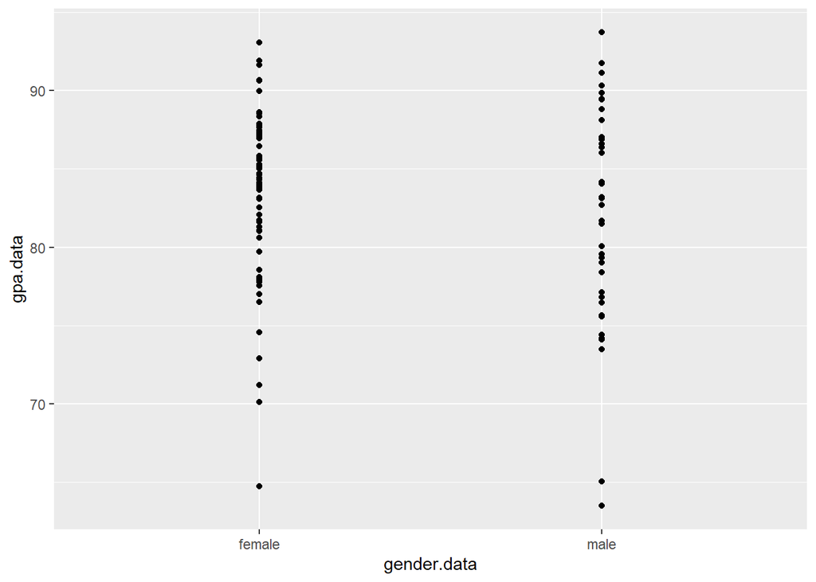

```r
gender.data<- Students_data$gender
gpa.data<- Students_data$GPA
ggplot(Students_data, aes(x =gender.data , y =gpa.data )) +
  geom_point()
```

##### Grafikten görüldüğü üzere en düşük GPA 65’ten biraz düşük olup bir erkek öğrenciye aittir. En yüksek GPA da bir erkek öğrenciye aittir ve 90’dan büyüktür. Verideki max min GPA notlarını bulduğumuz için grafikten yaklaşık değer söylemek yerine o notları da gösterebiliriz. Yani min olan GPA 63.49 ve max GPA da 93.71’dir. Grafikten bu değerleri nokta atışı söylemek mümkün olmayabilir ama max min fonksiyonu ile sorunu çözebiliriz.

#### Öğrencilerin ders başarılarının ortalamalarını yeni bir dataframede görelim.

```r
mean_lessons <- data.frame(
  m_algebra=mean(Students_data$Algebra),
  m_calculus1=mean(Students_data$Calculus1),
  m_calculus2=mean(Students_data$Calculus2),
  m_statistic=mean(Students_data$Statistics),
  m_probability=mean(Students_data$Probability),
  m_measure=mean(Students_data$Measure),
  m_FA=mean(Students_data$Functional_analysis)
)
mean_lessons
```

```
##   m_algebra m_calculus1 m_calculus2 m_statistic m_probability m_measure
## 1  76.05714     71.9619    78.94286    85.13333      83.87619   80.7619
##       m_FA
## 1 75.32381
```

##### Öğrencilerin istatistikte daha başarılı olduğu söylenebilir. Ortalamalara bakıldığında öğrencilerin analiz 1 dersinde daha az başarı gösterdikleri söylenebilir.

#### Sınıftaki öğrenci cinsiyet oranını görelim.

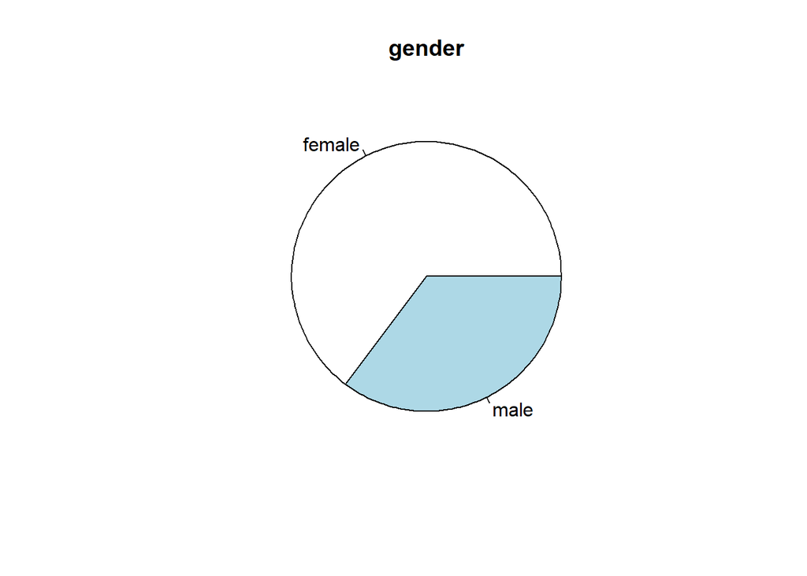

```r
gender_data <- table(Students_data$gender)
pie(gender_data,
    labels = c("female", "male"),
    main = "gender")
```

##### Sınıftaki öğrencilerin yarısından fazlası kız öğrencidir.

#### Sınıftaki öğrenci cinsiyet oranını bulalım.

```r
male <- sum(Students_data$gender == "male")
female <- sum(Students_data$gender == "female")
sum_gender <- male + female

male_ratio <- male / sum_gender
female_ratio <- female / sum_gender

cat("Erkek öğrenci oranı: ", male_ratio, "\n")
```

```
## Erkek öğrenci oranı:  0.352381
```

```r
cat("Kız öğrenci oranı: ", female_ratio, "\n")
```

```
## Kız öğrenci oranı:  0.647619
```

#### Cinsiyete göre istatistik notu dağılımını görelim

```r
library(ggplot2)
Students_data
```

```
## # A tibble: 105 x 17
##       ID class gender  race   GPA Algebra Calculus1 Calculus2 Statistics
##    <dbl> <chr> <chr>  <dbl> <dbl>   <dbl>     <dbl>     <dbl>      <dbl>
##  1  1141 A     male       1  73.5      64        81        87         60
##  2  1142 A     female     1  71.2      57        50        51         51
##  3  1143 A     female     2  74.6      47        48        71         60
##  4  1144 A     female     1  72.9      46        72        38         60
##  5  1145 A     female     1  70.1      49        45        63         60
##  6  1146 A     male       3  65.0      60        60        39         61
##  7  1147 A     male       4  77.1      60        43        52         63
##  8  1148 A     female     5  64.8      60        38        60         63
##  9  1149 B     female     5  77.9      61        60        66         68
## 10  1150 A     female     5  76.5      60        61        60         69
## # ... with 95 more rows, and 8 more variables: Probability <dbl>,
## #   Measure <dbl>, Functional_analysis <dbl>, from1 <chr>, from2 <chr>,
## #   from3 <chr>, from4 <dbl>, y <dbl>
```

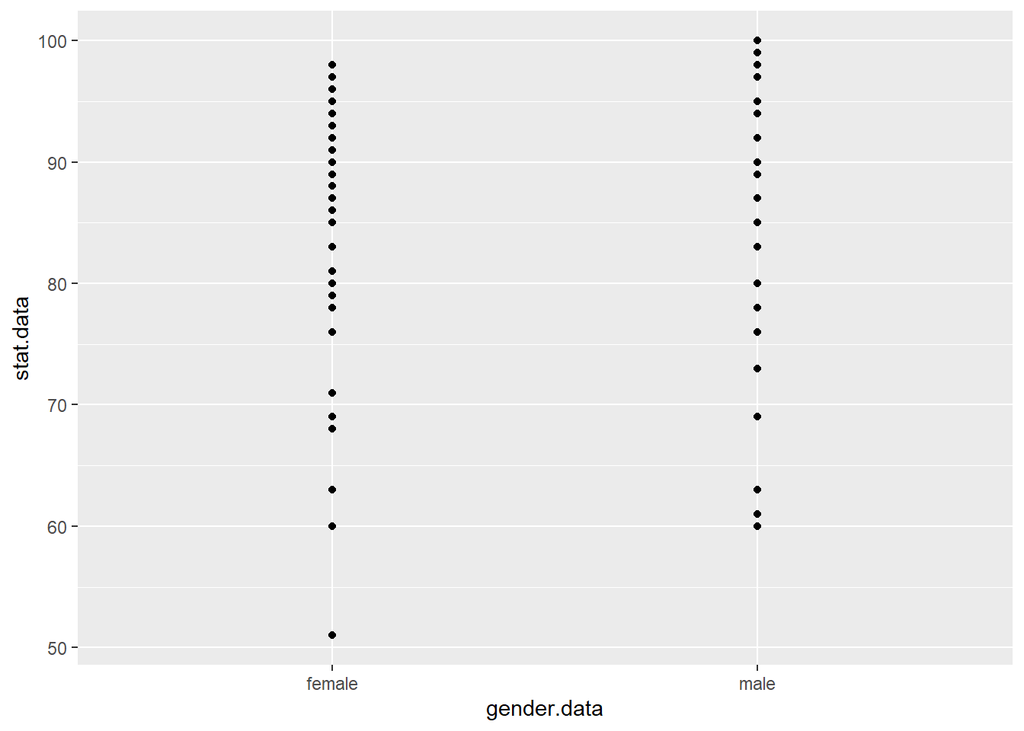

```r
gender.data<- Students_data$gender
stat.data<- Students_data$Statistics
ggplot(Students_data, aes(x =gender.data , y =stat.data )) +
  geom_point()
```

##### Grafikten görüldüğü üzere istatistikten en düşük not 50’den biraz fazla olup bir kız öğrenci tarafından alınmıştır. En yüksek not ise bir erkek öğrenciye ait olup 100’dür. Grafiğe bakarak 75-100 aralığındaki not sıklığının kız öğrencilerde daha fazla olduğunu gördüğümüzden kızların istatistik ortalamasının erkeklerden fazla olduğunu düşünebiliriz. Aşağıdaki kod ile bu düşüncemizin sağlamasını yapalım.

#### Cinsiyete göre istatistik not ortalamalarını görelim.

```r
gender_stats_data<- Students_data[, c("gender", "Statistics")]
gender_stats_data
```

```
## # A tibble: 105 x 2
##    gender Statistics
##    <chr>       <dbl>
##  1 male           60
##  2 female         51
##  3 female         60
##  4 female         60
##  5 female         60
##  6 male           61
##  7 male           63
##  8 female         63
##  9 female         68
## 10 female         69
## # ... with 95 more rows
```

```r
library(dplyr)
gender_stats_data %>%
  group_by(gender) %>%
  summarize(mean_stats = mean(Statistics))
```

```
## # A tibble: 2 x 2
##   gender mean_stats
##   <chr>       <dbl>
## 1 female       85.2
## 2 male         85.0
```

##### Ortalamalar birbirine çok yakın olsa da kız öğrencilerin istatistik dersindeki başarısı daha fazladır. Grafikten doğru bir çıkarım yapmışız demektir.

#### Sınıf şubelerine göre derslerin ortalamasını görelim.

```r
class_A_data <- Students_data[Students_data$class == "A", ]
class_A_data
```

```
## # A tibble: 76 x 17
##       ID class gender  race   GPA Algebra Calculus1 Calculus2 Statistics
##    <dbl> <chr> <chr>  <dbl> <dbl>   <dbl>     <dbl>     <dbl>      <dbl>
##  1  1141 A     male       1  73.5      64        81        87         60
##  2  1142 A     female     1  71.2      57        50        51         51
##  3  1143 A     female     2  74.6      47        48        71         60
##  4  1144 A     female     1  72.9      46        72        38         60
##  5  1145 A     female     1  70.1      49        45        63         60
##  6  1146 A     male       3  65.0      60        60        39         61
##  7  1147 A     male       4  77.1      60        43        52         63
##  8  1148 A     female     5  64.8      60        38        60         63
##  9  1150 A     female     5  76.5      60        61        60         69
## 10  1151 A     male       1  76.8      61        66        61         69
## # ... with 66 more rows, and 8 more variables: Probability <dbl>,
## #   Measure <dbl>, Functional_analysis <dbl>, from1 <chr>, from2 <chr>,
## #   from3 <chr>, from4 <dbl>, y <dbl>
```

```r
data_A <- c("Algebra", "Calculus1", "Calculus2", "Statistics", "Probability","Measure", "Functional_analysis")
colMeans(class_A_data[, data_A])
```

```
##             Algebra           Calculus1           Calculus2          Statistics
##            75.93421            72.69737            78.56579            85.13158
##         Probability             Measure Functional_analysis
##            83.13158            80.69737            75.14474
```

```r
class_B_data <- Students_data[Students_data$class == "B", ]
class_B_data
```

```
## # A tibble: 29 x 17
##       ID class gender  race   GPA Algebra Calculus1 Calculus2 Statistics
##    <dbl> <chr> <chr>  <dbl> <dbl>   <dbl>     <dbl>     <dbl>      <dbl>
##  1  1149 B     female     5  77.9      61        60        66         68
##  2  1152 B     female     1  83.6      73        75        76         71
##  3  1153 B     female     1  77        70        60        71         71
##  4  1156 B     female     6  82.1      72        63        70         76
##  5  1159 B     male       1  75.6      60        68        54         76
##  6  1161 B     male       1  75.6      63        64        71         78
##  7  1162 B     male       1  83.1      82        82        92         78
##  8  1163 B     female     1  79.7      72        68        55         78
##  9  1167 B     female     1  77.8      67        46        71         80
## 10  1171 B     female     1  85.0      76        75        85         83
## # ... with 19 more rows, and 8 more variables: Probability <dbl>,
## #   Measure <dbl>, Functional_analysis <dbl>, from1 <chr>, from2 <chr>,
## #   from3 <chr>, from4 <dbl>, y <dbl>
```

```r
data_B <- c("Algebra", "Calculus1", "Calculus2", "Statistics", "Probability","Measure", "Functional_analysis")
colMeans(class_B_data[, data_B])
```

```
##             Algebra           Calculus1           Calculus2          Statistics
##            76.37931            70.03448            79.93103            85.13793
##         Probability             Measure Functional_analysis
##            85.82759            80.93103            75.79310
```

##### A şubesinin sadece Analiz 1 dersinde B şubesinden başarılı olduğu, diğer derslerde B şubesinin daha başarılı olduğu görülmüştür.

#### Öğrencilerin en az başarı gösterdiği analiz 1 dersi için cinsiyete göre dağılımı görüp matematiksel sonuca ulaşalım.

```r
library(ggplot2)
Students_data
```

```
## # A tibble: 105 x 17
##       ID class gender  race   GPA Algebra Calculus1 Calculus2 Statistics
##    <dbl> <chr> <chr>  <dbl> <dbl>   <dbl>     <dbl>     <dbl>      <dbl>
##  1  1141 A     male       1  73.5      64        81        87         60
##  2  1142 A     female     1  71.2      57        50        51         51
##  3  1143 A     female     2  74.6      47        48        71         60
##  4  1144 A     female     1  72.9      46        72        38         60
##  5  1145 A     female     1  70.1      49        45        63         60
##  6  1146 A     male       3  65.0      60        60        39         61
##  7  1147 A     male       4  77.1      60        43        52         63
##  8  1148 A     female     5  64.8      60        38        60         63
##  9  1149 B     female     5  77.9      61        60        66         68
## 10  1150 A     female     5  76.5      60        61        60         69
## # ... with 95 more rows, and 8 more variables: Probability <dbl>,
## #   Measure <dbl>, Functional_analysis <dbl>, from1 <chr>, from2 <chr>,
## #   from3 <chr>, from4 <dbl>, y <dbl>
```

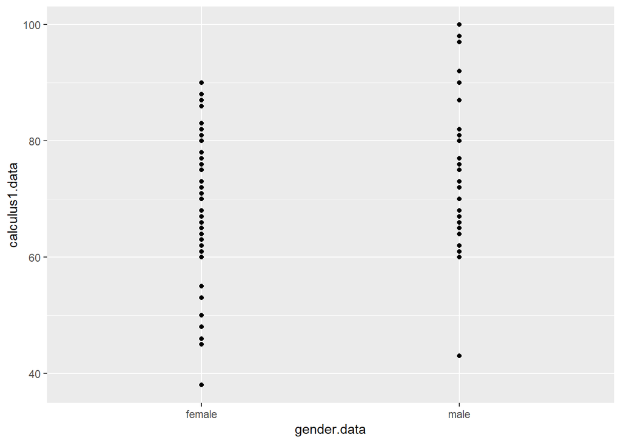

```r
gender.data<- Students_data$gender
calculus1.data<- Students_data$Calculus1
ggplot(Students_data, aes(x =gender.data , y =calculus1.data )) +
  geom_point()
```

##### Grafikten kız öğrencilerin analiz 1 dersindeki başarısının erkek öğrencilerin başarısından az olduğunu bariz görebiliriz.

```r
gender_calculus1_data<- Students_data[, c("gender", "Calculus1")]
gender_calculus1_data
```

```
## # A tibble: 105 x 2
##    gender Calculus1
##    <chr>      <dbl>
##  1 male          81
##  2 female        50
##  3 female        48
##  4 female        72
##  5 female        45
##  6 male          60
##  7 male          43
##  8 female        38
##  9 female        60
## 10 female        61
## # ... with 95 more rows
```

```r
library(dplyr)
gender_calculus1_data %>%
  group_by(gender) %>%
  summarize(mean_calculus1 = mean(Calculus1))
```

```
## # A tibble: 2 x 2
##   gender mean_calculus1
##   <chr>           <dbl>
## 1 female           70.5
## 2 male             74.6
```

##### Grafikten bu çıkarım yapılmıştı ve matematiksel sonuca da baktığımızda kız öğrencilerin analiz 1 dersindeki başarısı erkek öğrencilerin başarısından düşüktür deriz.

##### En yüksek GPA’ya sahip öğrencinin cinsiyetini, şubesini, en yüksek ve en düşük notları ve hangi dersler olduğunu bulalım.

```r
max_gpa_st <- Students_data[which.max(Students_data$GPA), ]
max_gpa_st
```

```
## # A tibble: 1 x 17
##      ID class gender  race   GPA Algebra Calculus1 Calculus2 Statistics
##   <dbl> <chr> <chr>  <dbl> <dbl>   <dbl>     <dbl>     <dbl>      <dbl>
## 1  1245 A     male       1  93.7      93        97        99        100
## # ... with 8 more variables: Probability <dbl>, Measure <dbl>,
## #   Functional_analysis <dbl>, from1 <chr>, from2 <chr>, from3 <chr>,
## #   from4 <dbl>, y <dbl>
```

##### En yüksek GPA’ya sahip öğrenci A şubesinden erkek bir öğrencidir. En yüksek notu istatistikten olup 100’dür. En düşük notu ise cebir dersinden olup 93’tür.

#### En düşük GPA’ya sahip öğrencinin cinsiyetini, şubesini, en yüksek ve en düşük notları ve hangi dersler olduğunu bulalım.

```r
min_gpa_st <- Students_data[which.min(Students_data$GPA), ]
min_gpa_st
```

```
## # A tibble: 1 x 17
##      ID class gender  race   GPA Algebra Calculus1 Calculus2 Statistics
##   <dbl> <chr> <chr>  <dbl> <dbl>   <dbl>     <dbl>     <dbl>      <dbl>
## 1  1219 A     male       1  63.5      81        61        17         92
## # ... with 8 more variables: Probability <dbl>, Measure <dbl>,
## #   Functional_analysis <dbl>, from1 <chr>, from2 <chr>, from3 <chr>,
## #   from4 <dbl>, y <dbl>
```

##### En düşük GPA’ya sahip öğrenci A şubesinden erkek bir öğrencidir. En yüksek notu istatistikten olup 92’dir. En düşük notu ise analiz 2 dersinden olup 17’dir.

#### Analiz 1 ve analiz 2 derslerinin notlarının ortalamasını analiz sütunu oluşturup dataframe’e ekleyelim.

```r
Students_data$calculus <- (Students_data$Calculus1 + Students_data$Calculus2) / 2
print(Students_data)
```

```
## # A tibble: 105 x 18
##       ID class gender  race   GPA Algebra Calculus1 Calculus2 Statistics
##    <dbl> <chr> <chr>  <dbl> <dbl>   <dbl>     <dbl>     <dbl>      <dbl>
##  1  1141 A     male       1  73.5      64        81        87         60
##  2  1142 A     female     1  71.2      57        50        51         51
##  3  1143 A     female     2  74.6      47        48        71         60
##  4  1144 A     female     1  72.9      46        72        38         60
##  5  1145 A     female     1  70.1      49        45        63         60
##  6  1146 A     male       3  65.0      60        60        39         61
##  7  1147 A     male       4  77.1      60        43        52         63
##  8  1148 A     female     5  64.8      60        38        60         63
##  9  1149 B     female     5  77.9      61        60        66         68
## 10  1150 A     female     5  76.5      60        61        60         69
## # ... with 95 more rows, and 9 more variables: Probability <dbl>,
## #   Measure <dbl>, Functional_analysis <dbl>, from1 <chr>, from2 <chr>,
## #   from3 <chr>, from4 <dbl>, y <dbl>, calculus <dbl>
```

#### Analiz sütunundan max notu ve bu öğrencinin diğer bilgilerini görelim.

```r
max_calculus_st <- Students_data[which.max(Students_data$calculus), ]
max_calculus_st
```

```
## # A tibble: 1 x 18
##      ID class gender  race   GPA Algebra Calculus1 Calculus2 Statistics
##   <dbl> <chr> <chr>  <dbl> <dbl>   <dbl>     <dbl>     <dbl>      <dbl>
## 1  1237 A     male       2  91.7      94       100        96         97
## # ... with 9 more variables: Probability <dbl>, Measure <dbl>,
## #   Functional_analysis <dbl>, from1 <chr>, from2 <chr>, from3 <chr>,
## #   from4 <dbl>, y <dbl>, calculus <dbl>
```

##### Analiz 1 ve analiz 2 derslerinin ortalaması olan analiz sütununun notlarına göre en yüksek not A sınıfından bir erkek öğrencinindir ve 2 dersinin ortalaması yani analiz notu 98’dir. Bu öğrencinin en yüksek analiz notu analiz 1 dersinden ve 100’dür. Analiz 2 dersi ise 96’dır.

#### Analiz sütunundan min notu ve bu öğrencinin diğer bilgilerini görelim.

```r
min_calculus_st <- Students_data[which.min(Students_data$calculus), ]
min_calculus_st
```

```
## # A tibble: 1 x 18
##      ID class gender  race   GPA Algebra Calculus1 Calculus2 Statistics
##   <dbl> <chr> <chr>  <dbl> <dbl>   <dbl>     <dbl>     <dbl>      <dbl>
## 1  1219 A     male       1  63.5      81        61        17         92
## # ... with 9 more variables: Probability <dbl>, Measure <dbl>,
## #   Functional_analysis <dbl>, from1 <chr>, from2 <chr>, from3 <chr>,
## #   from4 <dbl>, y <dbl>, calculus <dbl>
```